# Tipos de modelos: Predictivos vs Explicativos

02/05, 2020

## Modelos explicativos y predictivos

## Modelos estadísticos

- Simplificación numérica de la realidad
- Todos los modelos están equivocados, algunos son útiles
- Modelo no determinista que utiliza una muestra de una población para intentar determinar patrones de esta población.
  - ANOVA
  - regresión lineal
  - una regresión no lineal
- Poder explicativo != Poder predictivo
- Poder explivativo (\(R^2\))
- Poder Predictivo (\(R^2\), en una nueva base de datos)

## Ejemplo 1 Altura y sexo

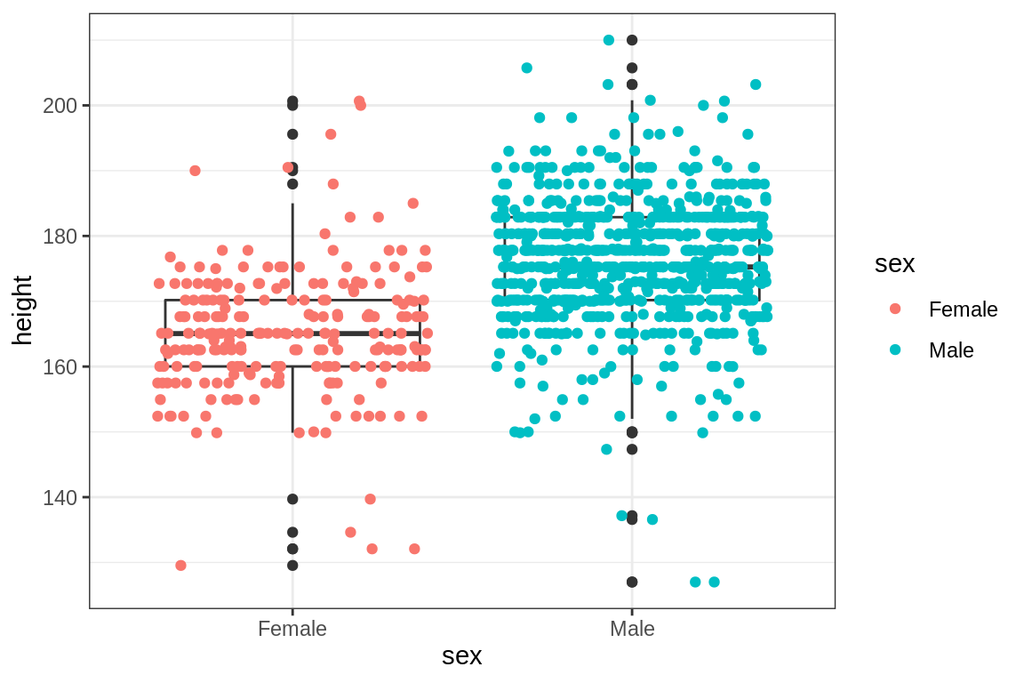

| r.squared | p.value | df |
| --- | --- | --- |
| 0.2 | 0 | 2 |

## Ejemplo 1 Altura y sexo

```r
aov(height ~ sex, data = heights) %>% broom::augment() %>%
    dplyr::select(height, sex, .fitted, .resid) %>%
    rename(Prediccion = .fitted, Diferencia = .resid) %>%
    kable(digits = 2) %>% kable_styling(bootstrap_options = c("striped"),
    full_width = F) %>% scroll_box(width = "800px",
    height = "400px")
```

| height | sex | Prediccion | Diferencia |
| --- | --- | --- | --- |
| 190.50 | Male | 176.06 | 14.44 |
| 177.80 | Male | 176.06 | 1.74 |
| 172.72 | Male | 176.06 | -3.34 |
| 187.96 | Male | 176.06 | 11.90 |
| 154.94 | Male | 176.06 | -21.12 |
| 165.10 | Female | 164.95 | 0.15 |
| 167.64 | Female | 164.95 | 2.69 |
| 157.48 | Female | 164.95 | -7.47 |
| 167.64 | Female | 164.95 | 2.69 |
| 170.18 | Male | 176.06 | -5.88 |
| 182.88 | Male | 176.06 | 6.82 |
| 182.88 | Male | 176.06 | 6.82 |
| 175.26 | Male | 176.06 | -0.80 |
| 172.72 | Male | 176.06 | -3.34 |
| 175.26 | Male | 176.06 | -0.80 |
| 167.64 | Male | 176.06 | -8.42 |
| 190.50 | Male | 176.06 | 14.44 |
| 162.56 | Female | 164.95 | -2.39 |
| 152.40 | Female | 164.95 | -12.55 |
| 170.18 | Male | 176.06 | -5.88 |
| 167.64 | Male | 176.06 | -8.42 |
| 162.56 | Male | 176.06 | -13.50 |
| 177.80 | Male | 176.06 | 1.74 |
| 185.42 | Male | 176.06 | 9.36 |
| 182.88 | Male | 176.06 | 6.82 |
| 175.26 | Male | 176.06 | -0.80 |
| 175.26 | Male | 176.06 | -0.80 |
| 182.88 | Male | 176.06 | 6.82 |
| 162.56 | Female | 164.95 | -2.39 |
| 182.88 | Male | 176.06 | 6.82 |

[output cut: 1020 more lines]

## Ejemplo 2 temperautra explicada por fecha

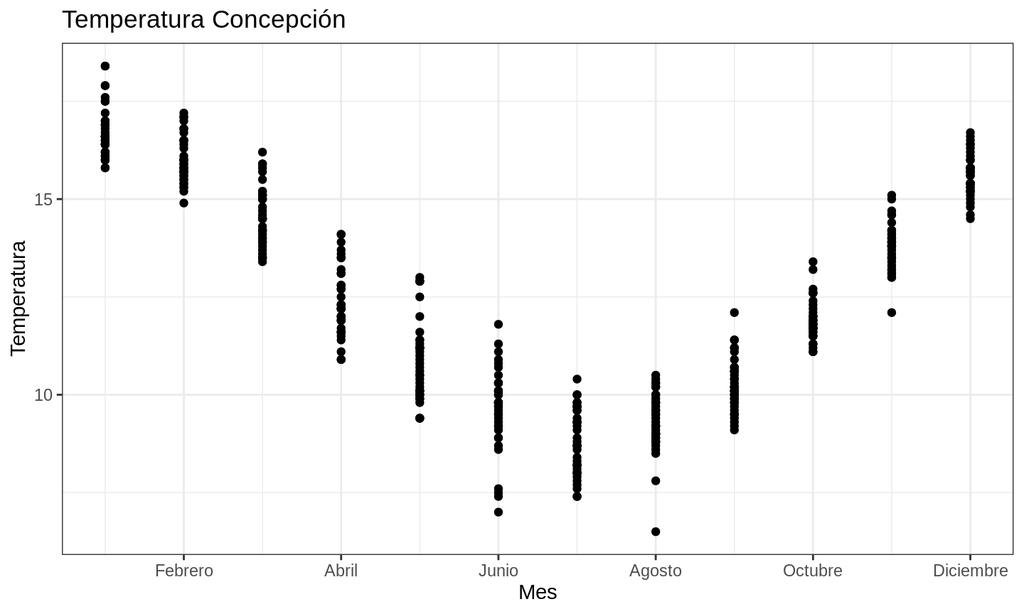

## Ejemplo 2 temperautra explicada por fecha

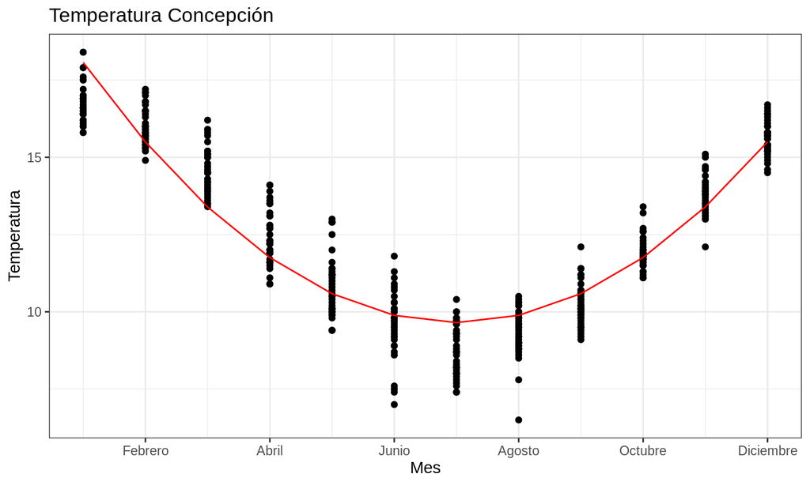

## Ejemplo 3

¿Podemos explicar o predecir la eficiencia de combustible (*mpg*) a partir de los caballos de fuerza (*hp*) de un Vehículo?

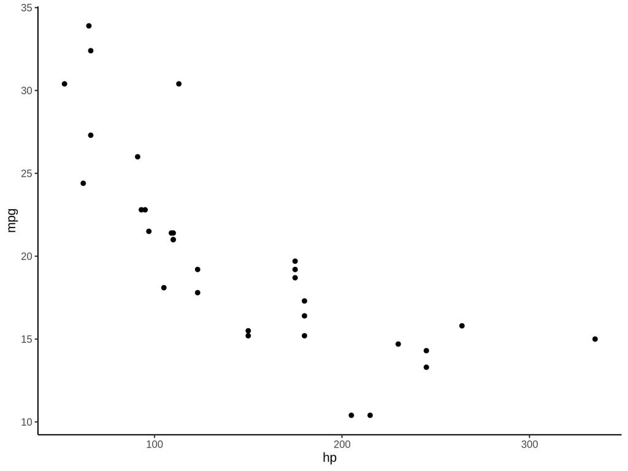

## Datos de entrenamiento y de prueba

- Para mostrar poder explicativo vs predictivo
- Datos de entrenamiento (ajustar el modelo y ver poder explicativo)
- Datos de prueba (Ver el poder predictivo)

```r
set.seed(2018)
index <- sample(1:nrow(mtcars), size = round(nrow(mtcars)/2))

Train <- mtcars[index, ]

Test <- mtcars[-index, ]
```

\[mpg = \beta_1 hp + \beta_2 hp^2 + c\]

## Entrenamos el modelo

- Ajustemos un modelo lineal

```r
Modelo <- lm(mpg ~ hp + I(hp^2), data = Train)
```

## Poder explicativo:

- Veamos el poder explicativo

```r
glance(Modelo)
```

R cuadrado, valor de p y grados de libertad del modelo

| r.squared | p.value | df |
| --- | --- | --- |
| 0.7879861 | 4.18e-05 | 3 |

- podemos explicar un 78.8% de la variación en la eficiencia del vehículo.

## Observemos el modelo gráficamente

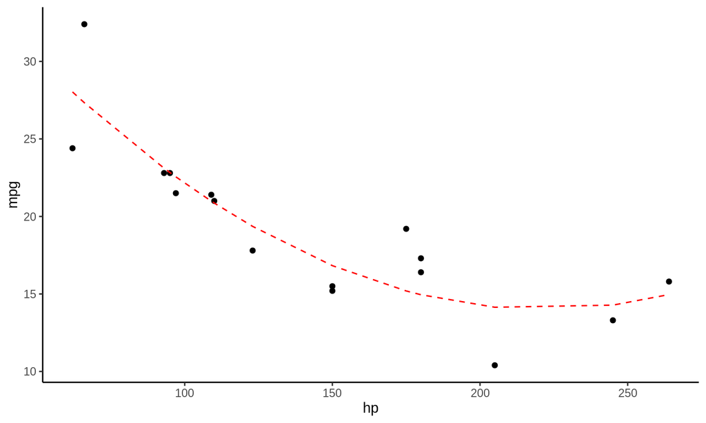

Los puntos representan las observaciones con las que se entrenó el modelo, la linea roja segmentada representa la predicción del modelo

## Poder Predictivo:

- Generemos una predicción en la base de datos de prueba

```r
Test$Pred <- predict(Modelo, Test)
Test <- Test %>% mutate(resid = mpg - Pred) %>% select(hp,
    mpg, Pred, resid)
```

| hp | mpg | Pred | resid |
| --- | --- | --- | --- |
| 110 | 21.0 | 20.86 | 0.14 |
| 110 | 21.4 | 20.86 | 0.54 |
| 175 | 18.7 | 15.19 | 3.51 |
| 105 | 18.1 | 21.49 | -3.39 |
| 245 | 14.3 | 14.28 | 0.02 |
| 123 | 19.2 | 19.36 | -0.16 |
| 180 | 15.2 | 14.95 | 0.25 |
| 215 | 10.4 | 14.01 | -3.61 |
| 230 | 14.7 | 14.02 | 0.68 |
| 52 | 30.4 | 29.84 | 0.56 |
| 65 | 33.9 | 27.51 | 6.39 |
| 66 | 27.3 | 27.34 | -0.04 |
| 91 | 26.0 | 23.40 | 2.60 |
| 113 | 30.4 | 20.50 | 9.90 |
| 175 | 19.7 | 15.19 | 4.51 |
| 335 | 15.0 | 21.01 | -6.01 |

## Poder Predictivo (Calculo)

```r
library(caret)
postResample(pred = Test$Pred, obs = Test$mpg)
```

```
##      RMSE  Rsquared       MAE
## 3.8741375 0.6805523 2.6437118
```

## Poder Predictivo (Visual)

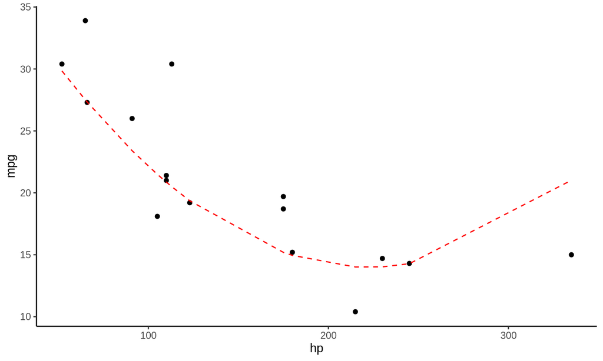

## Sobreajuste

## Que pasa al complejizar el modelo

\[mpg = \beta_1 hp + \beta_2 hp^2 + ... + \beta_12 hp^{12} c\]

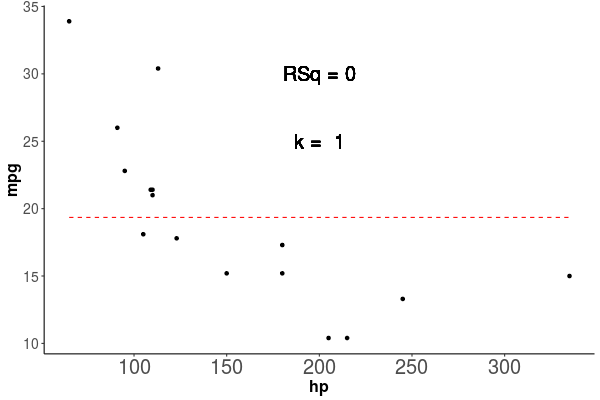

## Sobreajuste

- Al complejizar el modelo el poder explicativo aumenta (\(R^2\))
- No hay errores de explicación
- Solo es valido para los datos de entrenamiento (*Train*)

[figure not shown]

## ¿Cuando me puede interesar el maximizar el poder predictivo?

- Predicción de casos de COVID19
- Texto predictivo del celular
- Auto-corrector
- Efectos de cambio climático
- Detección de caras en redes sociales
- Eficiencia de medidas ante epidemias
- Maximizar metrica en base de prueba (*Test*)
- Machine learning

## ¿Cuando me puede interesar el maximizar el poder predictivo?

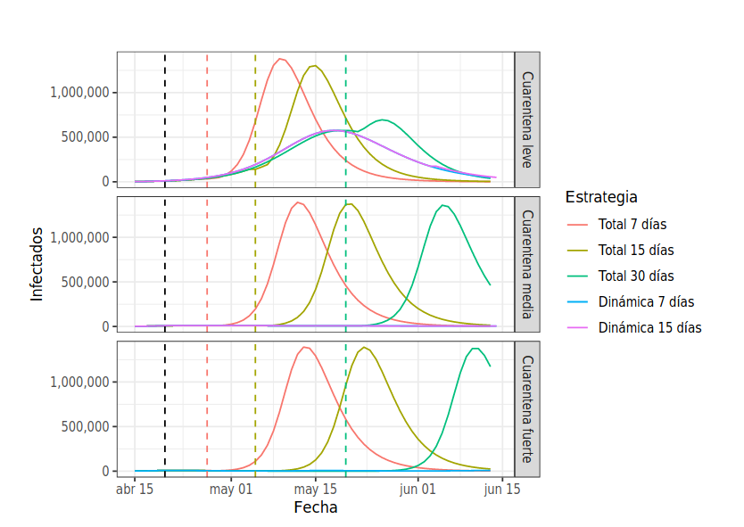

## ¿Cuando me puede interesar el maximizar el poder explicativo?

- Pruebas a hipótesis causales
- ¿Que causa el cambio climático?

En general para trabajar bajo esta aproximación debemos seguir los siguientes pasos:

- Generación de hipótesis (plural)
- Generación de modelos para cada hipótesis
- Interpretación de resultados en base a modelos e hipótesis

## Explicación o Predicción?

## Explicación o Predicción?

[figure not shown]

Que hacer?

[figure not shown]

## Criterio de Información de Akaike

\[AIC = 2k - \ln(L)\]

- \(K\) = Numero de parametros
- \(\ln(L)\) = Log likelihood

\[AICc = AIC + \frac{2k^2 + 2k}{n-k-1}\] * \(n\) = número de observaciones

## Calculo AICc

```r
library(MuMIn)
Modelo <- lm(mpg ~ hp + I(hp^2), data = Train)
AICc(Modelo)
```

```
## [1] 84.02319
```

## Relación entre AICc y R cuadrado

- \(R^2\) Siempre aumenta con \(K\)
- Cuando la pendiente de \(R^2\) vs \(K\) se aplana, se minimiza *AICc*

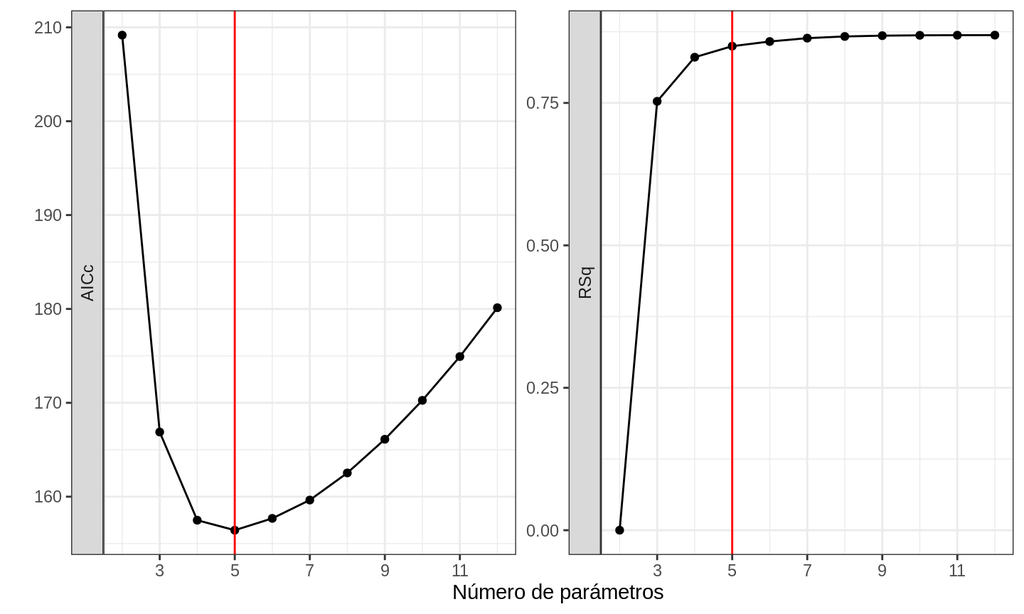

Relación entre AICc y R cuadrado

## Ejercicio

## Ejercicio

Tomando la base de datos `mtcars` explora la relacion entre AICc, \(R^2\) Exploratorio y \(R^2\) Predictivo.

Para eso genera un data frame con las siguientes columnas:

- AICc
- K
- \(R^2\) Exploratorio
- \(R^2\) Predictivo
- Id modelo

## Solución 1

## Resolviendo el Ejercicio

- Usaré los mismos *Train* y *Test* usados anteriormente

```r
set.seed(2018)
index <- sample(1:nrow(mtcars), size = round(nrow(mtcars)/2))
Train <- mtcars[index, ]
Test <- mtcars[-index, ]
```

## Resolviendo el Ejercicio para un modelo

- Generamos el data.frame a ser llenado

```r
DF <- tibble(Formula = NA, Model = NA, K = NA, R_2_Train = NA,
    R_2_Test = NA, AICc = NA)
```

- Guardamos el modelo como texto para usarlo despues

```r
DF$Formula <- "mpg ~ hp + wt"
```

- Ajustamos el modelo con train

```r
DF$Model <- list(lm(as.formula(DF$Formula), data = Train))
```

## Resolviendo el Ejercicio para un modelo (cont.)

- Agregamos los \(R_2\) y el AICc

```r
DF$K <- 3
DF$R_2_Train <- R2(pred = predict(DF$Model[[1]], Train),
    obs = Train$mpg)
DF$R_2_Test <- R2(pred = predict(DF$Model[[1]], Test),
    obs = Test$mpg)
DF$AICc <- AICc(DF$Model[[1]])
DF <- DF %>% select(-Model)
```

| Formula | K | R_2_Train | R_2_Test | AICc |
| --- | --- | --- | --- | --- |
| mpg ~ hp + wt | 3 | 0.7754265 | 0.8583897 | 84.94401 |

## Solución 2

## Resolviendo el Ejercicio para una lista de modelos

- Generamos el data.frame a ser llenado

```r
DF <- tibble(Formula = rep(NA, 3), Model = rep(NA,
    3), K = rep(NA, 3), R_2_Train = rep(NA, 3), R_2_Test = rep(NA,
    3), AICc = rep(NA, 3))
```

- Guardamos el modelo como texto para usarlo despues

```r
DF$Formula <- c("mpg ~ hp + wt", "mpg ~ hp + disp",
    "mpg ~ wt + disp")
```

- Ajustamos el modelo con train

```r
for (i in 1:nrow(DF)) {
    DF$Model[i] <- list(lm(as.formula(DF$Formula[i]),
        data = Train))
}
```

## Resolviendo el Ejercicio para una lista de modelos

- Agregamos los \(R_2\) y el AICc

```r
DF$K <- 3
for (i in 1:nrow(DF)) {
    DF$R_2_Train[i] <- R2(pred = predict(DF$Model[i][[1]],
        Train), obs = Train$mpg)
    DF$R_2_Test[i] <- R2(pred = predict(DF$Model[i][[1]],
        Test), obs = Test$mpg)
    DF$AICc[i] <- AICc(DF$Model[i][[1]])
}
DF <- DF %>% select(-Model)
```

| Formula | K | R_2_Train | R_2_Test | AICc |
| --- | --- | --- | --- | --- |
| mpg ~ hp + wt | 3 | 0.7754265 | 0.8583897 | 84.94401 |
| mpg ~ hp + disp | 3 | 0.7201421 | 0.7891400 | 88.46528 |
| mpg ~ wt + disp | 3 | 0.7130022 | 0.8182925 | 88.86835 |

## Solución 3

## Para todos los modelos

```r
Data <- list()
for (i in c(1:12)) {
    Data[[i]] <- tibble(Formula = purrr::map(as.data.frame(combn(c("cyl",
        "disp", "hp", "drat", "wt", "qsec", "vs", "am",
        "gear", "carb", "I(wt^2)", "I(hp^2)"), i)),
        ~paste(.x, collapse = "+")) %>% reduce(c),
        Model = purrr::map(as.data.frame(combn(c("cyl",
            "disp", "hp", "drat", "wt", "qsec", "vs",
            "am", "gear", "carb", "I(wt^2)", "I(hp^2)"),
            i)), ~paste(.x, collapse = "+")) %>% purrr::map(~paste("mpg ~",
            .x)) %>% purrr::map(as.formula) %>% purrr::map(~lm(.x,
            data = Train)), K = i + 1)
}
Data <- bind_rows(Data)
```

## Cont

```r
Data$R_2_Train <- NA
Data$R_2_Test <- NA
Data$AICc <- NA
for (i in 1:nrow(Data)) {
    Data$R_2_Train[i] <- R2(pred = predict(Data$Model[i][[1]],
        Train), obs = Train$mpg)
    Data$R_2_Test[i] <- R2(pred = predict(Data$Model[i][[1]],
        Test), obs = Test$mpg)
    Data$AICc[i] <- AICc(Data$Model[i][[1]])
}
Data <- Data %>% dplyr::select(-Model) %>% arrange(AICc)
```

[output not shown]

[output cut: 4065 more lines]

## Relaciones

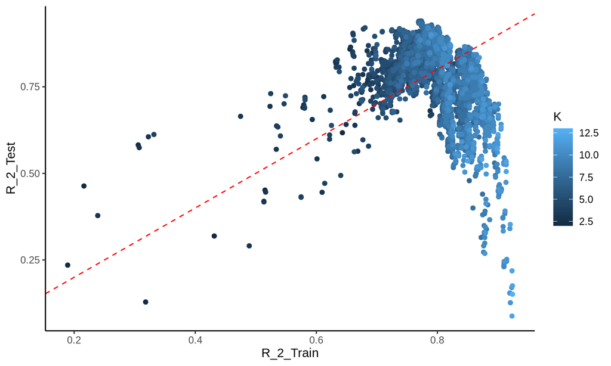

## Relaciones 2

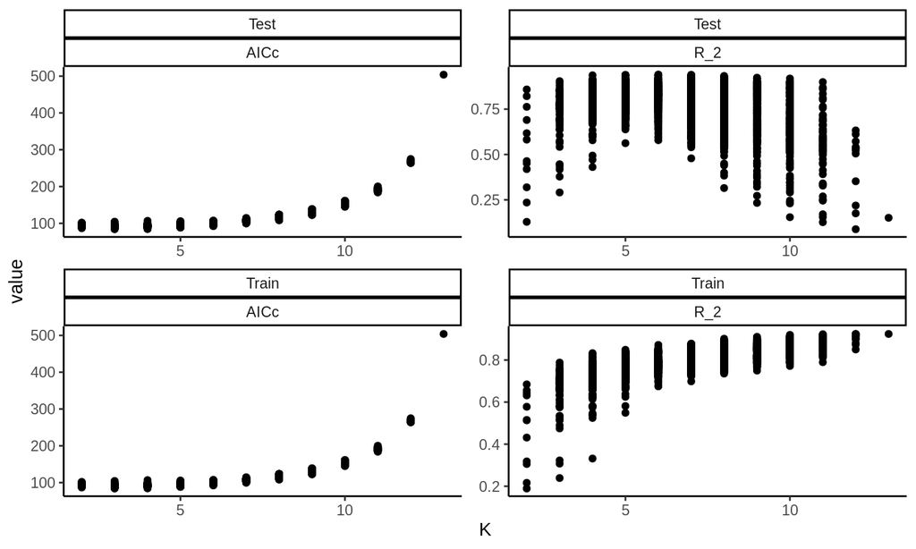